# Machine Learning: Motion Sensors

IvLL

July 11, 2016

# Project: Analysing Data From Wearable Devices

## Synopsis

The purpose of this study is to create a model to predict the movements of a particular exercise, the Unilateral Dumbbell Biceps Curls. The models do this by analysing datasets from kinetic sensors which can be found here: Training: https://d396qusza40orc.cloudfront.net/predmachlearn/pml-training.csv Testing: https://d396qusza40orc.cloudfront.net/predmachlearn/pml-testing.csv

The results of this study are that a Random Forest model was able to predict the test set near 100% accuracy.

## DownLoad Data

The Data was downloaded at the source and stored locally

```r
#train data
trainURL <- "https://d396qusza40orc.cloudfront.net/predmachlearn/pml-training.csv?accessType = DOWNLOAD"
download.file(trainURL, destfile="train.csv")

#test data
testURL <- "https://d396qusza40orc.cloudfront.net/predmachlearn/pml-testing.csv?accessType = DOWNLOAD"
download.file(testURL, destfile="test.csv")
```

## PrePreprocess the data

```r
Train1<- read.csv("train.csv",na.strings = c(""," ","NA"),header = TRUE)
Test2<- read.csv('test.csv',na.strings=c('','NA'))
Train2<-Train1[,!apply(Train1,2,function(x) any(is.na(x)) )]
Train<-Train2[,-c(1:7)]
Train$classe <- as.factor(Train$classe)
dim(Train)
```

```
## [1] 19622    53
```

## Analysis of data and Variables

```r
#load required libraries
library(caret)
library(randomForest)
library(e1071)
```

### Data Paritioning

We begin by partition the training set into a 60/40 training and validation set. The dataset is large enough (19622 entries) to allow for this split.

```r
# partition the train set
set.seed(1994)
partrain <- createDataPartition(y=Train$classe,p=0.6, list=FALSE)
train <- Train[partrain,]
test <- Train[-partrain,]
dim(test)
```

```
## [1] 7846   53
```

```r
dim(train)
```

```
## [1] 11776    53
```

```r
# samtrain<-train[sample(nrow(train),5000),] # for testing code
```

### Modeling the Data

```r
rf<-randomForest(classe~., data=train, method='class')
trainpreds<-predict(rf,Train, type='class')
trainconf<-confusionMatrix(trainpreds,Train$classe)
save(trainconf,file='test.RData')
```

### Test set performance

Using the model we trained on the training set we make predictions on the test set and find that it 99.5% accurate. The plot shows the points that were predicted incorrectly.

```r
testpreds <-predict(rf,test,type='class')
testconf <-confusionMatrix(testpreds,test$classe)

sum(testpreds!=test$classe)/length(test$classe)
```

```
## [1] 0.005098139
```

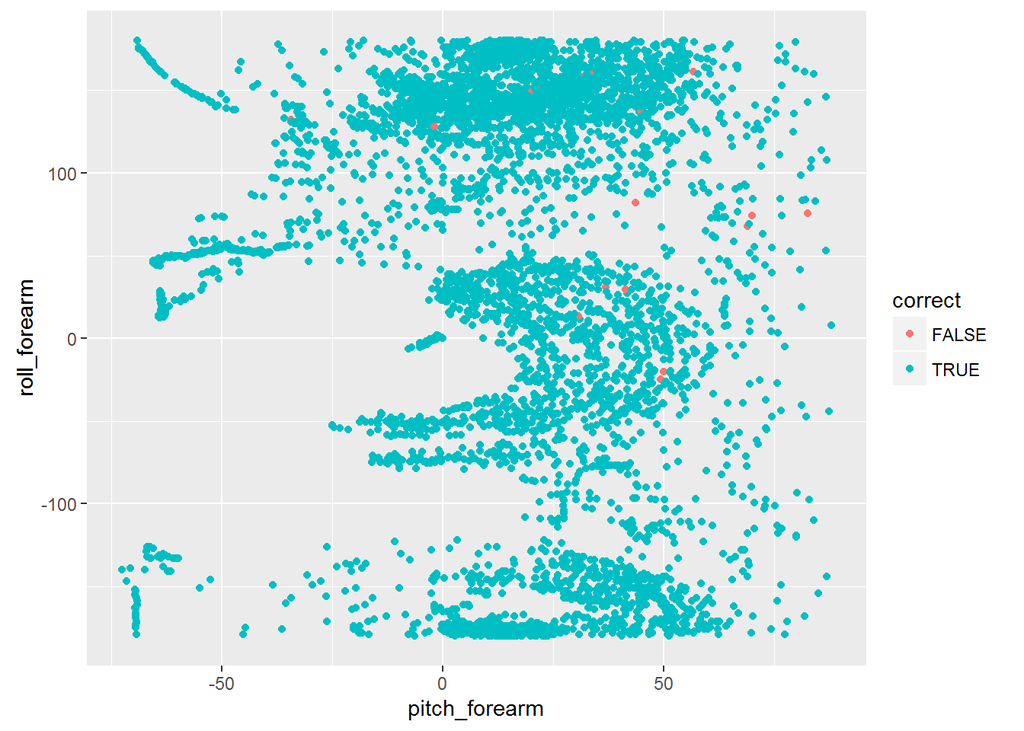

```r
correct<-testpreds == test$classe
tpreds<-qplot(pitch_forearm, roll_forearm, colour=correct,data=test)
tpreds
```

### Prediction on the 20 observations

The model is used to predict the values for the quality of lifts for the 20 observations.

```r
Test1 <- Test2[,!apply(Test2,2,function(x) any(is.na(x)) )]
Test <- Test1[,-c(1:7)]
pred_final<-predict(rf,Test,type='class')
save(pred_final,file='testpredictedc.RData')
```